# TUGAS 2

# Library

```r
library(readxl)
```

```r
library(ggplot2)
library(corrplot)
library(car)
library(lmtest)
library(tidyverse)
library(tidyr)
library(dplyr)
library(GGally)
library(olsrr)
```

# Data

## Import Data

```r
df <- read_excel("D:\\Mine\\Kuliah Journey\\Semester 4\\Analisis Regresi\\anime_2022_clean.xlsx")
df <- df[, c("Score", "Episodes", "Rank", "Popularity", "Favorites", "Scored By", "Members")]
head(df)
```

```
## # A tibble: 6 × 7
##   Score Episodes  Rank Popularity Favorites `Scored By` Members
##   <dbl>    <dbl> <dbl>      <dbl>     <dbl>       <dbl>   <dbl>
## 1  6.28        8  7518       2880       215        4066   50891
## 2  5.95        4  9056      10696         2         751    1986
## 3  5.29       11 11364      14692         0         196     532
## 4  4.67       12 12341       6075        16        1673    9881
## 5  6.85        6  4631       3518       114       14427   35227
## 6  6.69       12  5396       4330        64        4638   22670
```

## Penyesuaian Peubah

```r
colnames(df) <- c("Y", paste0("X", 1:6))
head(df)
```

```
## # A tibble: 6 × 7
##       Y    X1    X2    X3    X4    X5    X6
##   <dbl> <dbl> <dbl> <dbl> <dbl> <dbl> <dbl>
## 1  6.28     8  7518  2880   215  4066 50891
## 2  5.95     4  9056 10696     2   751  1986
## 3  5.29    11 11364 14692     0   196   532
## 4  4.67    12 12341  6075    16  1673  9881
## 5  6.85     6  4631  3518   114 14427 35227
## 6  6.69    12  5396  4330    64  4638 22670
```

# 1. Deskripsi Data

## Sumber Data

Data yang digunakan dalam analisis ini adala data sekunder yang bersumber dari MyAnimeList (MAL), situs komunitas anime global. Pengumpulan data dilakukan dengan metode scraping.

## Deskripsi Variabel

Dataset ini berisi 526 observasi yang merepresentasikan berbagai judul anime, dengan 7 variabel numerik yang digunakan dalam analisis sebagai berikut:

1. Score ($Y$)  
   Nilai rating atau skor anime yang diberikan oleh pengguna dengan skala 1-10.
2. Episodes ($X_1$)  
   Jumlah episode dari setiap judul anime.
3. Rank ($X_2$)  
   Peringkat anime berdasarkan skor.
4. Popularity ($X_3$)  
   Peringkat popularitas anime berdasarkan jumlah pengguna yang menambahkan anime tersebut ke dalam daftar.
5. Favorites ($X_4$)  
   Jumlah pengguna yang menjadikan anime tersebut favorit.
6. Scored By ($X_5$)  
   Jumlah pengguna yang memberikan penilaian terhadap anime.
7. Members ($X_6$)  
   Jumlah total pengguna yang menambahkan anime tersebut ke dalam daftar.

## Tipe data

Memastikan setiap variabel memiliki tipe data yang sesuai.

```r
str(df)
```

```
## tibble [526 × 7] (S3: tbl_df/tbl/data.frame)
##  $ Y : num [1:526] 6.28 5.95 5.29 4.67 6.85 6.69 6.87 8.46 6.25 6.87 ...
##  $ X1: num [1:526] 8 4 11 12 6 12 1 1 13 6 ...
##  $ X2: num [1:526] 7518 9056 11364 12341 4631 ...
##  $ X3: num [1:526] 2880 10696 14692 6075 3518 ...
##  $ X4: num [1:526] 215 2 0 16 114 64 35 352 98 109 ...
##  $ X5: num [1:526] 4066 751 196 1673 14427 ...
##  $ X6: num [1:526] 50891 1986 532 9881 35227 ...
```

Pengecekan tipe data dari setiap variabel. Berdasarkan hasil, dapat diketahui bahwa setiap variabel yang digunakan bertipe numerik.

## Pengecekan Missing Value

Mengetahui apakah ada data yang hilang untuk menjaga kualitas hasil analisis.

```r
colSums(is.na(df))
```

```
##  Y X1 X2 X3 X4 X5 X6
##  0  0  0  0  0  0  0
```

Pengecekan missing value dari setiap variabel. Berdasarkan hasil, dapat diketahui bahwa tidak terdapat missing value pada semua variabel.

## Statistik Deskriptif

Gambaran umum mengenai data dan membantu memahami karakteristik dari data.

```r
summary(df)
```

```
##        Y               X1               X2              X3
##  Min.   :3.790   Min.   :  1.00   Min.   :    2   Min.   :   88
##  1st Qu.:6.170   1st Qu.:  2.00   1st Qu.: 2103   1st Qu.: 2586
##  Median :6.730   Median : 12.00   Median : 5183   Median : 6122
##  Mean   :6.806   Mean   : 13.64   Mean   : 5203   Mean   : 7012
##  3rd Qu.:7.397   3rd Qu.: 13.00   3rd Qu.: 8011   3rd Qu.:11408
##  Max.   :9.070   Max.   :136.00   Max.   :12637   Max.   :17641
##        X4                X5                 X6
##  Min.   :    0.0   Min.   :   106.0   Min.   :    272
##  1st Qu.:    5.0   1st Qu.:   385.2   1st Qu.:   1518
##  Median :   42.0   Median :  2867.5   Median :   9697
##  Mean   :  990.9   Mean   : 32054.2   Mean   :  73019
##  3rd Qu.:  335.0   3rd Qu.: 20285.8   3rd Qu.:  62259
##  Max.   :41416.0   Max.   :815326.0   Max.   :1349178
```

```r
sapply(df, sd)
```

```
##            Y           X1           X2           X3           X4           X5
## 8.597783e-01 1.660048e+01 3.404149e+03 4.820285e+03 3.849292e+03 8.558771e+04
##           X6
## 1.627713e+05
```

Secara umum, data memiliki variasi yang cukup besar, terdapat kemungkinan sebaran tidak normal dan memiliki pencilan.

## Visualisasi

### Histogram

Melihat bentuk sebaran dari tiap variabel.

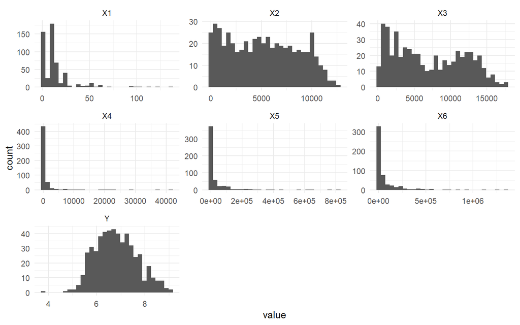

```r
df %>%
  select(where(is.numeric)) %>%
  pivot_longer(cols = everything()) %>%
  ggplot(aes(x = value)) +
  geom_histogram(bins = 30) +
  facet_wrap(~name, scales = "free") +
  theme_minimal()
```

Berdasarkan plot histogram, diketahui bahwa variabel $Y$ cenderung menyebar normal, sedangkan variabel $X_1$, $X_4$, $X_5$, dan $X_6$ cenderung menyebar ke kanan dan variabel $X_2$ dan $X_3$ cenderung menyebar ke kanan, tetapi ada indikasi bimodal.

### Boxplot

Mengecek outlier dengan menggunakan boxplot dari tiap variabel.

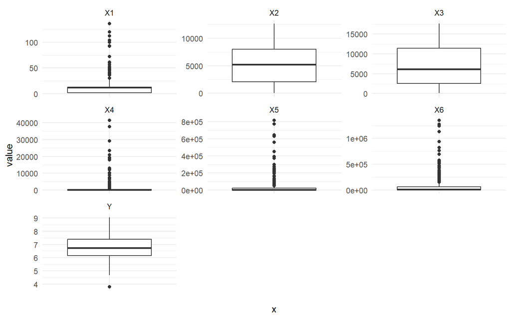

```r
df %>%
  select(where(is.numeric)) %>%
  pivot_longer(cols = everything()) %>%
  ggplot(aes(x = "", y = value)) +
  geom_boxplot() +
  facet_wrap(~name, scales = "free_y") +
  theme_minimal()
```

# 2. Eksplorasi Data

## Hubungan tiap Variabel Prediktor dengan Respon

Mengetahui seberapa kuat hubungan masing-masing variabel penjelas terhadap respon dan distribusi tiap variabel.

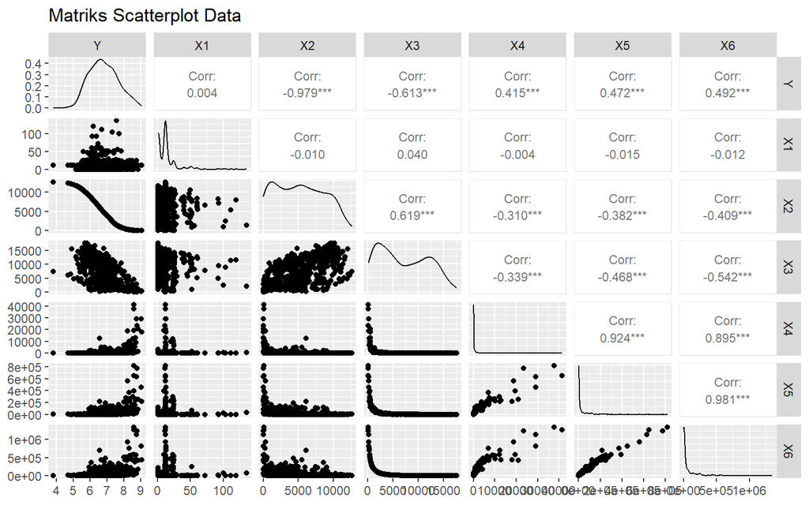

```r
ggpairs(df,
        upper = list(continuous = wrap('cor', size = 3)),
        title = "Matriks Scatterplot Data")
```

## Matriks Korelasi

Mengetahui kekuatan dan arah hubungan antar variabel serta deteksi awal indikasi multikolinearitas.

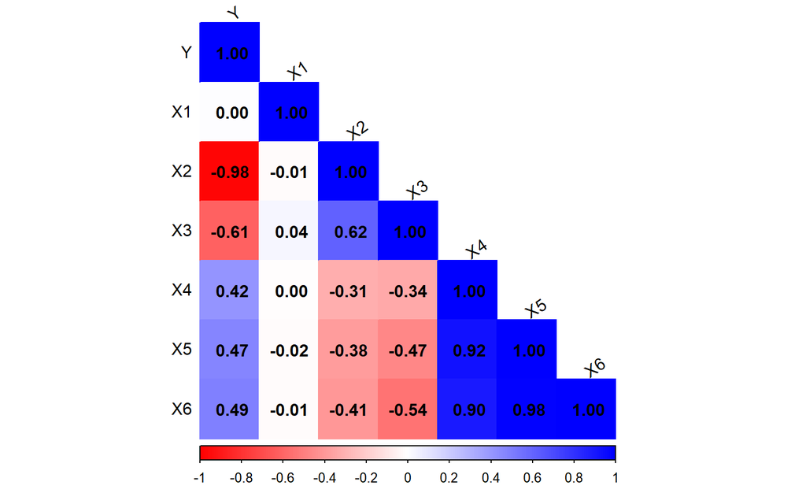

```r
cor_matrix <- cor(df, use = "complete.obs")

corrplot(cor_matrix, method = "color", type = "lower",
         col = colorRampPalette(c("red", "white", "blue"))(200),
         addCoef.col = "black", tl.col = "black", tl.srt = 35)
```

Berdasarkan hasil matriks antar variabel dengan matriks korelasi menunjukkan bahwa peubah respon Score ($Y$), memiliki hubungan positif dengan Favorites ($X_4$), Scored By($X_5$), dan Members ($X_6$) serta hubungan negatif dengan Rank ($X_2$) dan Popularity ($X_3$). Di lain sisi, korelasi peubah respon dengan Episodes ($X_1$) tidak ada.

Selain itu, terdapat korelasi tinggi antar peubah penjelas, sebagai berikut:  
1. Rank ($X_2$) dengan Popularity ($X_3$) sebesar 0.62  
2. Favorites ($X_4$) dengan Scored By($X_5$) sebesar 0.92  
3. Favorites ($X_4$) dengan Members ($X_6$) sebesar 0.90  
4. Scored By($X_5$) dengan Members ($X_6$) sebesar 0.98

Korelasi yang tinggi antar peubah penjelas ini, mengindikasikan adanya multikolinearitas yang dapat mempengaruhi akurasi model yang akan dibentuk.

# 3. Pemodelan Regresi

Persamaan model regresi linear berganda adalah sebagai berikut:
$$Y = \beta_0 + \beta_1 X_1 + \beta_2 X_2 + \beta_3
X_3 + \beta_4 X_4 + \beta_5 X_5 + \beta_6 X_6 + \epsilon$$
$Y$: Peubah respon (Score)
$\beta_0$: Konstanta (Intercept)
$\beta_1, \beta_2, \beta_3, \beta_4, \beta_5, \beta_6$: Koefisien regresi untuk masing-masing penjelas
$X_1$: Episodes
$X_2$: Rank
$X_3$: Popularity
$X_4$: Favorites
$X_5$: Scored By
$X_6$: Members
$\epsilon$: Galat atau sisaan (error)

```r
model1 = lm(formula = Y ~ ., data = df)
summary(model1)
```

```
##
## Call:
## lm(formula = Y ~ ., data = df)
##
## Residuals:
##      Min       1Q   Median       3Q      Max
## -1.20393 -0.08061 -0.01350  0.06487  0.82472
##
## Coefficients:
##               Estimate Std. Error  t value Pr(>|t|)
## (Intercept)  8.009e+00  1.835e-02  436.385  < 2e-16 ***
## X1          -2.827e-04  3.791e-04   -0.746   0.4562
## X2          -2.404e-04  2.383e-06 -100.876  < 2e-16 ***
## X3           3.438e-06  2.021e-06    1.701   0.0895 .
## X4           2.793e-05  4.443e-06    6.285 6.93e-10 ***
## X5           1.098e-07  4.590e-07    0.239   0.8110
## X6          -5.135e-08  2.274e-07   -0.226   0.8215
## ---
## Signif. codes:  0 '***' 0.001 '**' 0.01 '*' 0.05 '.' 0.1 ' ' 1
##
## Residual standard error: 0.1438 on 519 degrees of freedom
## Multiple R-squared:  0.9723, Adjusted R-squared:  0.972
## F-statistic:  3040 on 6 and 519 DF,  p-value: < 2.2e-16
```

Persamaan model regresi:

$$\hat{Y} = 8.009 - 0.0002827X_1 -
0.0002404X_2 + 0.000003438X_3 + 0.00002793X_4 + 0.0000001098X_5 -
0.00000005135X_6$$

## Interpretasi

Berdasarkan hasil pendugaan parameter pada model regresi linear berganda, kita dapat menguraikan kontribusi setiap peubah penjelas terhadap skor anime pada selang kepercayaan 95% adalah sebagai berikut:

1. $\beta_0$ (Intercept) = 8.009: Jika semua variabel penjelas bernilai nol. Maka, Score dari suatu anime adalah 8.009 satuan.
2. Episodes ($X_1$) = -0.0002827: Setiap kenaikan satu episode dari suatu anime dan variabel lainnya dianggap tetap, maka Scorenya berkurang 0.0002827 satuan.
3. Rank ($X_2$) = -0.0002404: Setiap kenaikan satu peringkat dari suatu anime dan variabel lainnya dianggap tetap, maka Scorenya akan berkurang sebesar 0.0002404 satuan.
4. Popularity ($X_3$) = 0.000003438: Setiap kenaikan satu peringkat popularity dari satu anime dan variabel lainnya dianggap tetap, maka Scorenya akan bertambah sebesar 0.000003438 satuan.
5. Favorites ($X_4$) = 0.00002793: Setiap kenaikan satu satuan favorite dari suatu anime dan variabel lainnya dianggap tetap, maka Scorenya akan bertambah sebesar 0.00002793 satuan.
6. Scored By ($X_5$) = 0.0000001098: Setiap kenaikan satu orang yang memberikan skor dan variabel lainnya dianggap tetap, maka skor dari suatu anime akan bertambah sebesar 0.0000001098 satuan.
7. Members ($X_6$) = -0.00000005135: Setiap kenaikan satu orang yang memasukkan ke daftar dan variabel lainnya dianggap tetap, maka skor dari suatu anime akan berkurang sebesar 0.00000005135 satuan.
8. Multiple R-squared = 0.9723: Artinya, model menjelaskan 97.23% variasi dari peubah, sedangkan sisanya berasal dari luar model. Sehingga, kita dapat mengatakan bahwa model sudah cukup baik.

Selain itu, pada model ini, dapat dilihat bahwa secara simultan, minimal terdapat satu peubah penjelas yang berpengaruh signifikan terhadap peubah respon.

# 4. Pengujian Hipotesis Parameter

## Hipotesis

$H_0$: $\beta_i = 0$ (Peubah penjelas $X_i$ tidak berpengaruh signifikan terhadap Score)  
$H_1$: $\beta_i \neq 0$ (Peubah penjelas $X_i$ berpengaruh signifikan terhadap Score)

## Uji Parsial

Mengetahui apakah masing-masing variabel prediktor secara individu berpengaruh signifikan terhadap variabel respon.

```r
summary(model1)$coefficients
```

```
##                  Estimate   Std. Error      t value     Pr(>|t|)
## (Intercept)  8.009312e+00 1.835377e-02  436.3852134 0.000000e+00
## X1          -2.827131e-04 3.791499e-04   -0.7456500 4.562165e-01
## X2          -2.404200e-04 2.383325e-06 -100.8758496 0.000000e+00
## X3           3.438104e-06 2.020667e-06    1.7014698 8.945372e-02
## X4           2.792898e-05 4.443415e-06    6.2854771 6.933379e-10
## X5           1.097775e-07 4.589485e-07    0.2391935 8.110499e-01
## X6          -5.134656e-08 2.274429e-07   -0.2257559 8.214802e-01
```

```r
p_values <- summary(model1)$coefficients[,4]
```

```r
hasil <- data.frame(
  Variabel = rownames(summary(model1)$coefficients),
  Estimate = summary(model1)$coefficients[,1],
  p_value = summary(model1)$coefficients[,4],
  Keputusan = ifelse(summary(model1)$coefficients[,4] < 0.05,
                     "Signifikan", "Tidak signifikan")
)
hasil
```

```
##                Variabel      Estimate      p_value        Keputusan
## (Intercept) (Intercept)  8.009312e+00 0.000000e+00       Signifikan
## X1                   X1 -2.827131e-04 4.562165e-01 Tidak signifikan
## X2                   X2 -2.404200e-04 0.000000e+00       Signifikan
## X3                   X3  3.438104e-06 8.945372e-02 Tidak signifikan
## X4                   X4  2.792898e-05 6.933379e-10       Signifikan
## X5                   X5  1.097775e-07 8.110499e-01 Tidak signifikan
## X6                   X6 -5.134656e-08 8.214802e-01 Tidak signifikan
```

# 5. Diagnostik Model

## Normalitas

### QQ Plot

Eksplorasi grafik membandingkan sebaran sisa dengan sebaran normal untuk menguji asumsi normalitas.

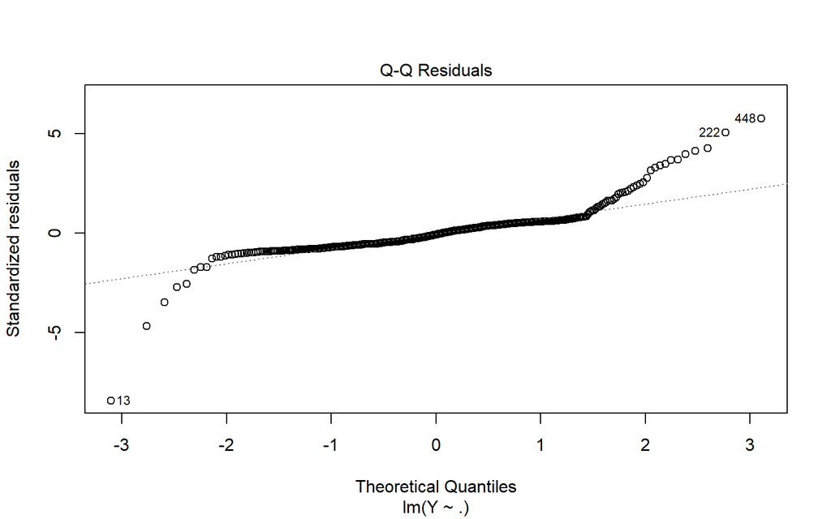

```r
plot(model1,2)
```

### Shapiro-Wilk

Uji formal untuk mengecek apakah suatu data mengikuti distribusi normal atau tidak dengan membandingkan pola data dengan pola data normal ideal.

```r
shapiro.test(model1$residuals)
```

```
##
##  Shapiro-Wilk normality test
##
## data:  model1$residuals
## W = 0.80525, p-value < 2.2e-16
```

### Interpretasi

Berdasarkan QQ-plot, amatan cenderung tidak mengikuti garis normal sehingga sisaan tidak menyebar normal. Berdasarkan uji formal Shapiro-Wilk, nilai p-value < 0.05 sehingga dinyatakan asumsi normal tidak terpenuhi.

## Homoskedastisitas

### Plot Sisaan vs Y duga

Eksplorasi grafik membandingkan sebaran sisa dengan fitted untuk menguji asumsi homoskedastisitas.

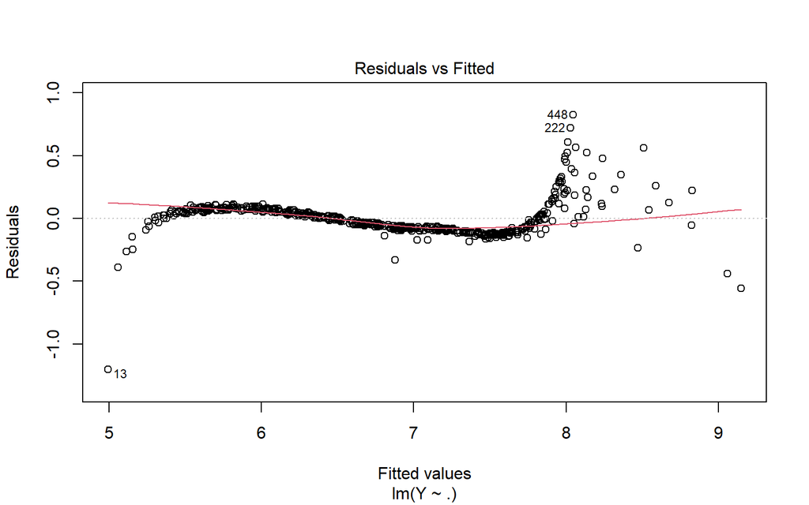

```r
plot(model1,1)
```

### T-test

T-test untuk menguji asumsi nilai harapan sisaan sama dengan nol.

```r
t.test(model1$residuals,mu = 0,conf.level = 0.95)
```

```
##
##  One Sample t-test
##
## data:  model1$residuals
## t = -2.5041e-15, df = 525, p-value = 1
## alternative hypothesis: true mean is not equal to 0
## 95 percent confidence interval:
##  -0.01224967  0.01224967
## sample estimates:
##     mean of x
## -1.561416e-17
```

### BP-Test

Uji formal untuk mengecek apakah suatu data memenuhi asumsi homoskedastisitas atau tidak dengan melihat apakah variansi residual dipengaruhi oleh variabel independen.

```r
bptest(model1)
```

```
##
##  studentized Breusch-Pagan test
##
## data:  model1
## BP = 31.004, df = 6, p-value = 2.531e-05
```

### Interpretasi

Berdasarkan plot, diketahui nilai sisaan menyebar di sekitar nol sehingga nilai harapan sisaan sama dengan nol. Lebar pita tidak sama dan plot cenderung berbentuk corong sehingga sisaan tidak homogen. Nilai p pada uji t sama dengan 1 > 0.05, sehingga dinyatakan asumsi nilai harapan sisaan sama dengan nol terpenuhi. Berdasarkan BP-Test, karena p-value < 0.05, maka asumis homoskedastisitas tidak terpenuhi.

## Saling Bebas

### Plot Sisaan vs Urutan

Eksplorasi grafik untuk menguji asumsi autokorelasi dengan membandingkan sisaan dengan urutan.

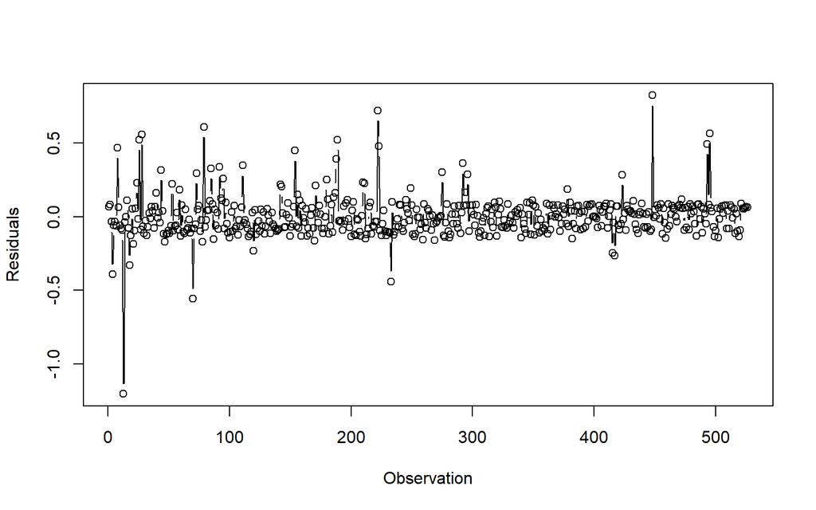

```r
plot(x = 1:dim(df)[1],
     y = model1$residuals,
     type = 'b',
     ylab = "Residuals",
     xlab = "Observation")
```

### Durbin Watson

Uji Durbin–Watson digunakan untuk memastikan bahwa residual bersifat independen.

```r
dwtest(model1)
```

```
##
##  Durbin-Watson test
##
## data:  model1
## DW = 1.8086, p-value = 0.01328
## alternative hypothesis: true autocorrelation is greater than 0
```

### Interpretasi

Berdasarkan plot terlihat bahwa residu tersebar di sekitar nol secara acak, hal ini menunjukkan bahwa secara visual, asumsi autokorelasi terpenuhi. Akan tetapi, terdapat indikasi autokorelasi karena hampir menyerupai pola autokorelasi positif. Berdasarkan hasil uji Durbin-Watson, diperoleh nilai statistik DW sebesar 1.8086 dengan p-value 0.01328. Karena p-value < 0.05, maka H0 ditolak, yang berarti terdapat autokorelasi positif pada residual model.

## Multikolinearitas

### Nilai VIF

VIF mengukur seberapa besar varians koefisien regresi karena adanya korelasi antar variabel bebas.

```r
vif(model1)
```

```
##        X1        X2        X3        X4        X5        X6
##  1.005302  1.670389  2.407512  7.423846 39.154746 34.780337
```

### Akar Ciri

Melihat struktur hubungan antar variabel bebas.

```r
x <- df[-1]
r <- cor(x)
(ev <- eigen(r)$values)
```

```
## [1] 3.42834983 1.08224352 1.00098683 0.38392567 0.09032001 0.01417414
```

```r
# Simultan
if ((max(ev) / min(ev)) <= 100) {
  cat("Tidak ada multikolinearitas\n")
} else if ((max(ev) / min(ev)) > 100 & (max(ev) / min(ev)) <= 1000) {
  cat("Ada multikolinearitas yang lemah\n")
} else {
  cat("Ada multikolinearitas yang kuat\n")
}
```

```
## Ada multikolinearitas yang lemah
```

```r
# Parsial
if (all((max(ev) / ev) <= 1000)) {
  cat("Tidak ada multikolinearitas\n")
} else {
  cat("Ada multikolinearitas pada peubah penjelas ke:", which((max(ev) / ev) > 1000), "\n")
}
```

```
## Tidak ada multikolinearitas
```

### Interpretasi

Berdasarkan nilai VIF, terdapat indikasi multikolinearitas pada variabel Scored By($X_5$) dengan Members ($X_6$) karena lebih besar dari 10. Akan tetapi, dari perhitungan dengan menggunakan akar ciri, terdapat multikolinearitas lemah secara simultan, tetapi pada parsial tidak ada multikolinearitas.

## Outlier

Mengukur seberapa aneh suatu observasi dibanding pola umum dengan menggunakan rstudent (studentized deleted residual).

```r
#fungsi
ri_stud <- rstudent(model1)
ri_stan <- rstandard(model1)
hii_fungsi <- hatvalues(model1)

#manual
X <- model.matrix(model1)
X_inv_xt <- X %*% solve(t(X) %*% X) %*% t(X)
hii_manual <- diag(X_inv_xt)
anova_model <- anova(model1)
s <- sqrt(anova_model["Residuals", "Mean Sq"])
ei <- model1$residuals
ri_manual <- ei/(s*sqrt(1-hii_manual))

nilai <- data.frame(ri_stud, ri_stan, ri_manual, hii_fungsi, hii_manual)
nilai
```

```
##          ri_stud      ri_stan    ri_manual  hii_fungsi  hii_manual
## 1    0.465559204  0.465910904  0.465910904 0.009736056 0.009736056
## 2    0.572926980  0.573298117  0.573298117 0.005049686 0.005049686
## 3   -0.241354390 -0.241573662 -0.241573662 0.009756836 0.009756836
## 4   -2.753503931 -2.736208751 -2.736208751 0.018485447 0.018485447
## 5   -0.412900606 -0.413230970 -0.413230970 0.005093277 0.005093277
## 6   -0.241090215 -0.241309277 -0.241309277 0.004341416 0.004341416
## 7   -0.423509089 -0.423844311 -0.423844311 0.005048449 0.005048449
## 8    3.299275334  3.268297072  3.268297072 0.008983923 0.008983923
## 9    0.453928199  0.454275800  0.454275800 0.007401911 0.007401911
## 10  -0.402166915 -0.402492088 -0.402492088 0.004867339 0.004867339
## 11  -0.549555896 -0.549925810 -0.549925810 0.005221274 0.005221274
## 12  -0.626688342 -0.627055296 -0.627055296 0.004598398 0.004598398
## 13  -9.080209776 -8.441916661 -8.441916661 0.016912799 0.016912799
## 14  -0.257394508 -0.257626364 -0.257626364 0.003515458 0.003515458
```

[output cut: 512 more lines]

```r
for (i in 1:dim(nilai)[1]){
  absri <- abs(nilai[,2])
  pencilan <- which(absri > 2)
}
pencilan
```

```
##  [1]   4   8  13  18  26  28  44  70  73  79  85  92 111 154 188 189 222 223 233
## [20] 275 292 296 448 493 495
```

## Leverage

Menunjukkan seberapa jauh posisi X suatu observasi dari pusat data

```r
n <- dim(df)[1]
p <- length(model1$coefficients)

for (i in 1:dim(nilai)[1]){
  cutoff <- 2*p/n
  titik_leverage <- which(hii_fungsi > cutoff)
}
titik_leverage
```

```
##  16  17  18  25  28  38  39  47  53  70  74  78  92  93  95 100 111 114 120 163
##  16  17  18  25  28  38  39  47  53  70  74  78  92  93  95 100 111 114 120 163
## 211 223 233 236 244 294 298 346 350 440 468
## 211 223 233 236 244 294 298 346 350 440 468
```

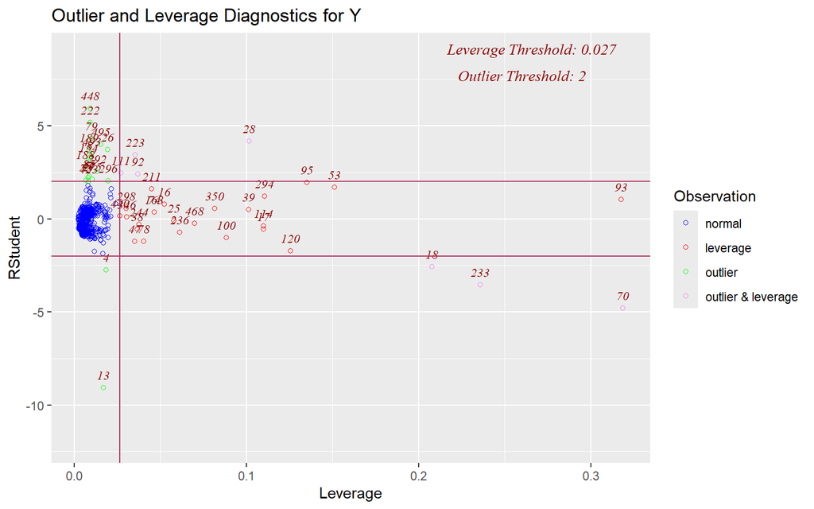

```r
ols_plot_resid_lev(model1)
```

### Interpretasi

Berdasarkan perhitungan, amatan ke-4, 8, 13, 18, 26, 28, 44, 70, 73, 79, 85, 92, 111, 154, 188, 189, 222, 223, 233, 275, 292, 296, 448, 493, 495 terindikasi sebagai pencilan karena nilai mutlak ri lebih dari dua. Selain itu, berdasarkan perhitungan, amatan ke-16, 17, 18, 25, 28, 38, 39, 47, 53, 70, 74, 78, 92, 93, 95, 100, 111, 114, 120, 163, 211, 223, 233, 236, 244, 294, 298, 346, 350, 440, dan 468 terdeteksi sebagai leverage karena nilai hii > 2p/n. Dan hal ini dikonfirmasi dengan visualisasi grafik.

## Amatan Berpengaruh

### Jarak Cook

Mengukur seberapa besar perubahan seluruh model regresi jika satu observasi dihapus.

```r
di <- cooks.distance(model1)
f <- qf(0.05,p,n-p, lower.tail = F)
data.frame(di, di>f)
```

```
##               di di...f
## 1   3.048876e-04  FALSE
## 2   2.383011e-04  FALSE
## 3   8.214257e-05  FALSE
## 4   2.014344e-02  FALSE
## 5   1.248828e-04  FALSE
## 6   3.627196e-05  FALSE
## 7   1.302179e-04  FALSE
## 8   1.383344e-02  FALSE
## 9   2.198425e-04  FALSE
## 10  1.131950e-04  FALSE
## 11  2.267567e-04  FALSE
## 12  2.594908e-04  FALSE
## 13  1.751489e-01  FALSE
## 14  3.344983e-05  FALSE
```

[output cut: 512 more lines]

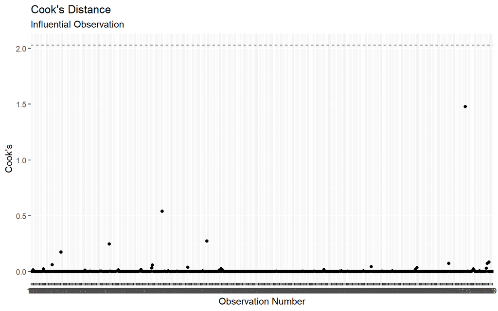

```r
cooks_crit = f
model_cooks <- cooks.distance(model1)
df <- data.frame(obs = names(model_cooks),
                 cooks = model_cooks)
ggplot(df, aes(y = cooks, x = obs)) +
  geom_point() +
  geom_hline(yintercept = cooks_crit, linetype="dashed") +
  labs(title = "Cook's Distance",
       subtitle = "Influential Observation ",
       x = "Observation Number",
       y = "Cook's")
```

### Interpretasi

Pemeriksaan amatan berpengaruh dengan jarak cook tidak dihasilkan nilai yang melebihi ambang batas.

### DFBETAS

Mengukur perubahan tiap koefisien regresi jika satu observasi dihapus.

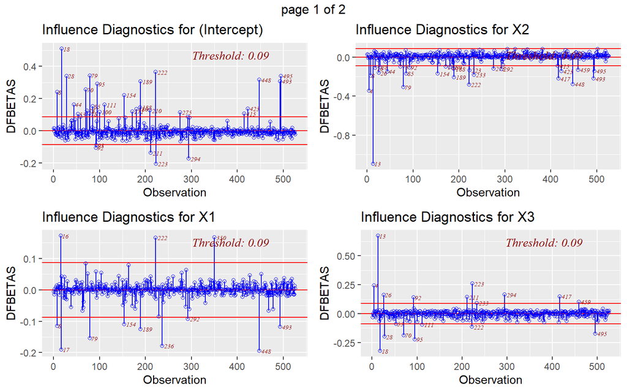

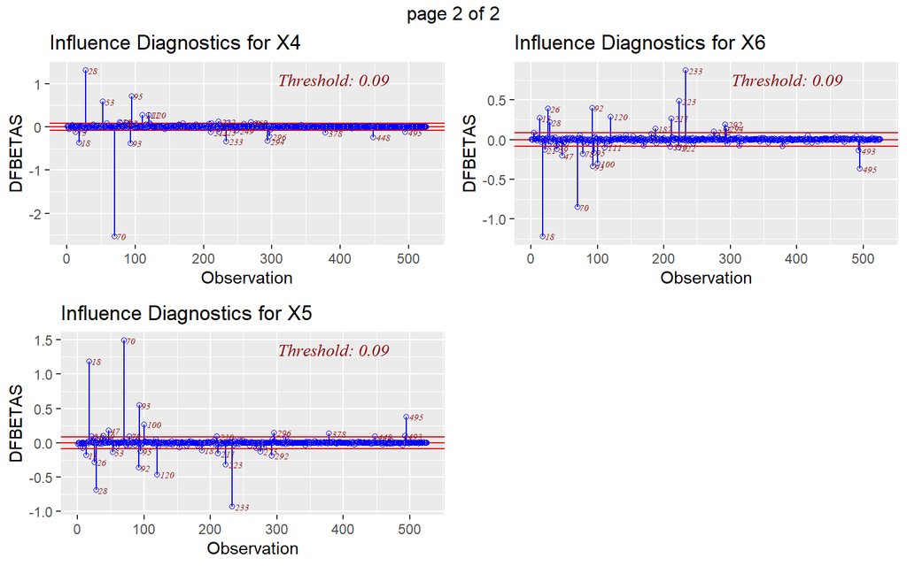

```r
ols_plot_dfbetas(model1)
```

### Interpretasi

Pengaruh observasi terhadap setiap koefisien regresi, sehingga ada output untuk setiap parameter regresi. DFBETAS mengukur seberapa besar koefisien regresi berubah jika suatu observasi dihapus dari model. Terlihat beberapa amatan yang melebihi ambang batas sehingga nilai-nilai tersebut riskan jika disisihkan.

### DFFITS

Mengukur perubahan nilai prediksi akibat menghapus satu observasi.

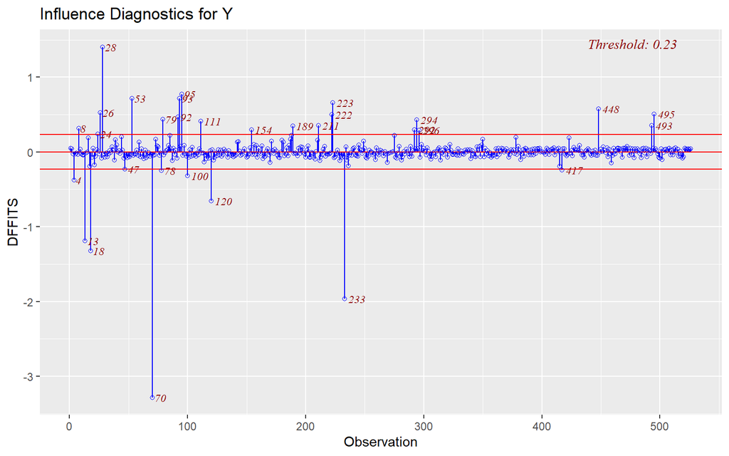

```r
ols_plot_dffits(model1)
```

```r
DFFITSi <- dffits(model1)

amatan_berpengaruh <- vector("list", dim(nilai)[1])
for (i in 1:dim(nilai)[1]) {
  cutoff <- 2 * sqrt((p / n))
  amatan_berpengaruh[[i]] <- which(abs(DFFITSi) > cutoff)
}
berpengaruh <- unlist(amatan_berpengaruh)
amatan_berpengaruh <- sort(unique(berpengaruh))
amatan_berpengaruh
```

```
##  [1]   4   8  13  18  24  26  28  47  53  70  78  79  92  93  95 100 111 120 154
## [20] 189 211 222 223 233 292 294 296 417 448 493 495
```

### Interpretasi

Hasil DFFITS menunjukkan pengaruh observasi terhadap nilai prediksi Y sehingga hanya menghasilkan satu output. Berdasarkan perhitungan, 4, 8, 13, 18, 24, 26, 28, 47, 53, 70, 78, 79, 92, 93, 95, 100, 111, 120, 154, 189, 211, 222, 223, 233, 292, 294, 296, 417, 448, 493, dan 495 termasuk ke dalam amatan berpengaruh sehingga riskan jika disisihkan. Perlu ditelusuri lebih lanjut.

# 6. Interpretasi Hasil Diagnostik

Terdapat indikasi pelanggaran asumsi normalitas dan homoskedastisitas secara pasti. Selain itu, terdapat indikasi pelanggaran asumsi multikolinearitas dan residu saling bebas berdasarkan uji formal. Untuk mengatasi asumsi normalitas dan heteroskedastisitas yang tak terpenuhi dapat menggunakan transformasi. Selain itu, untuk multikolinearitas bisa diatasi dengan menghapus atau mengurangi variabel yang memiliki korelasi tinggi, atau menggunakan metode alternatif seperti regularisasi. Pada masalah autokorelasi, pendekatan yang dapat dilakukan adalah menggunakan model yang mampu menangani korelasi residual, seperti Generalized Least Squares (GLS), atau menambahkan variabel yang relevan ke dalam model.

# 7. Kesimpulan

Secara umum, meskipun asumsi tidak terpenuhi dan perlu dilakukan analisis lebih lanjut, hasil analisis menunjukkan bahwa model regresi yang dibangun memiliki kemampuan yang sangat baik dalam menjelaskan variasi variabel respon (Y), terlihat dari nilai koefisien determinasi yang tinggi. Namun, berdasarkan uji parsial, hanya beberapa variabel prediktor yang berpengaruh signifikan terhadap Y, yaitu X2 dan X4, sementara variabel lainnya tidak menunjukkan pengaruh yang signifikan secara statistik. Hubungan yang terbentuk menunjukkan bahwa perubahan pada variabel-variabel tertentu, khususnya yang berkaitan dengan peringkat dan tingkat ketertarikan pengguna, memiliki kontribusi nyata terhadap perubahan nilai skor anime. Selain itu, perlu tindakan lebih lanjut untuk mengatasi asumsi yang tidak terpenuhi dengan cara, seperti transformasi, menghapus variabel penjelas yang nilai VIFnya tinggi, dan menerapkan GLS untuk meningkatkan akurasi model.